# **Effect of Refrigeration on Alzheimer’s Disease Biomarker Measurements in Plasma**

AAIC 2024

Ramiro Eduardo Rea Reyes, PhD

rreareyes@medicine.wisc.edu

# Materials and Methods

## Sample collection

Samples were collected prospectively from N = 30 Wisconsin Registry for Alzheimer’s Prevention (WRAP) and Wisconsin Alzheimer’s Disease Research Center (WADRC) participants as part of their routine baseline or follow-up visit. Blood was collected by venipuncture into three 10 mL EDTA tubes then gently inverted 8-10 times to mix. Samples were then centrifuged at 2000 x g for 10 minutes at 4 °C and the plasma was divided into cryovials (Sarstedt Part # 72.730.005) in 0.5 mL aliquots. Samples were processed within 1 hour of the blood draw.

For each participant, one aliquot was placed directly into the -80 °C freezer and two aliquots were placed in the refrigerator at 4 °C. After 48 hours, one aliquot was transferred to the -80 °C freezer while the other remained in the refrigerator. After 72 hours, the last aliquot was transferred to the -80 °C freezer, where they remained until the completion of the study.

## Sample analysis

On the day of analysis, the samples were removed from the freezer and thawed to room temperature. Samples were analyzed in single measure on a Quanterix HD-X using the Neurology 4-plex E assay (Quanterix Part #103670, Lot # 503768) and the ALZpath pTau217 Simoa assay (Quanterix Part # 104570, Lot # MAB231122) according to the kit instructions. To assess within-plate and between-plate variability, a control plasma sample (separate from kit controls) was analyzed in duplicate on each plate.

For the Neurology 4-plex E assay, the within-plate coefficient of variation (CV) ranged from 0.8% to 7.4% and the between-plate CV ranged from 0.8% to 5.1%. For the pTau217 assay, the within-plate CV was 5.3% and the between-plate CV was 5.0%.

## Statistical Analysis

### Repeated measures ANOVA with follow-up paired comparisons

We wanted to assess if the time spent in refrigeration before freezing had a significant effect in the detected concentration of different molecules relevant for AD research. For this purpose, we first ran, we a one-way repeated measures ANOVA, with the assay readings as the outcomes, and refrigeration condition as predictor, for each of the targets of interest:

$$\begin{aligned}
\text{Assay reading} & \sim \operatorname{Refrigeration condition}
\end{aligned}$$

Where assay reading is a continuous variable containing the concentration from the different targets of interest ($pTau217$, $NfL$, $GFAP$, $A\beta_{40}$, $A\beta_{42}$) or the ratio between $\frac{A\beta_{42}}{A\beta_{40}}$. On the other hand, refrigeration condition is a categorical variable with 3 levels (0 hrs, 48 hrs, 72 hrs), which represent the amount of time that the blood sample spent in refrigeration before freezing. For those analysis that showed significant difference between conditions, we ran paired follow-up comparisons between the refrigeration times. In the context of this analysis, a significant negative difference between a pair of conditions would suggest a reduction in the target concentration as a consecuence of the time spent refrigerated but not frozen.

### ICC

Additonally, we ran intraclass correlations between the three refrigeration conditions, to assess the reliability of the readings from the samples. The ICC is a value between 0 and 1. ICC values less than 0.5 are indicative of poor reliability, values between 0.5 and 0.75 indicate moderate reliability, values between 0.75 and 0.9 indicate good reliability, and values greater than 0.90 indicate excellent reliability. In the case of our samples, low reliability indicates lack of consistency in the readings, therefore a change in the target concentration due to the time spent without being frozen.

# Results

## $pTau217$

We did not find a significant difference between refrigeration levels and excellent reliability between the readings $pTau217$.

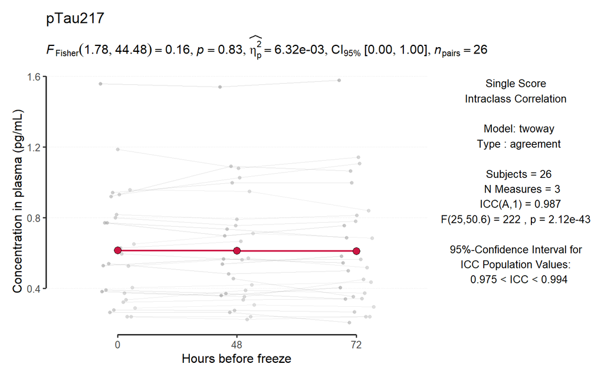

## Neurofilament light chain ($NfL$)

We did not find a significant difference between refrigeration levels and excellent reliability between the readings for $NfL$.

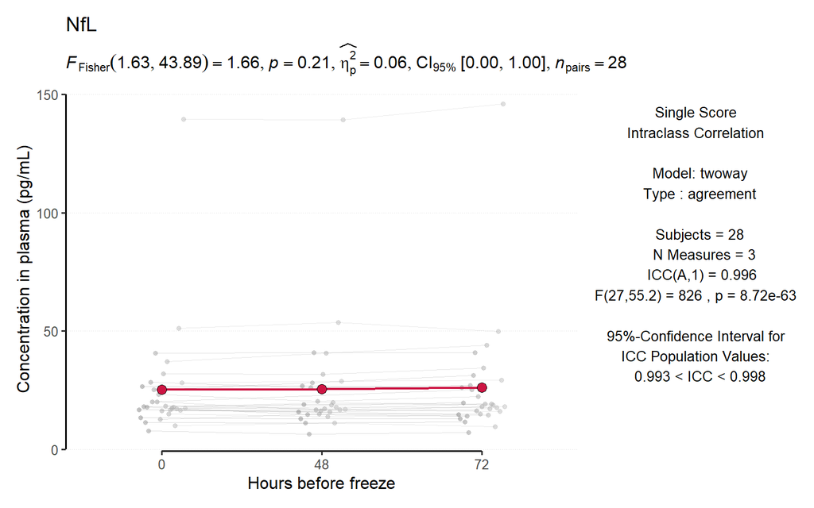

## Glial fibrillary acidic protein ($GFAP$)

We did not find a significant difference between refrigeration levels and excellent reliability between the readings for $GFAP$.

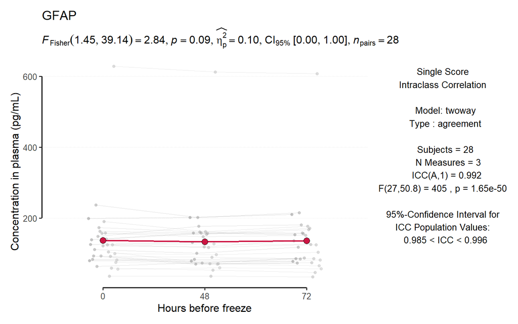

## Amyloid $\beta_{40}$ ($A\beta_{40}$)

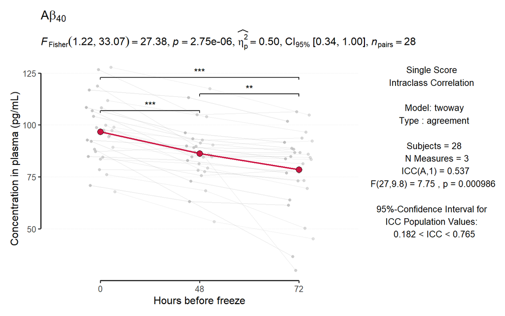

## Amyloid $\beta_{42}$ ($A\beta_{42}$)

We found a significant difference between samples frozen immediately and samples refrigerated for 48 hrs, and 72 hrs in the concentration of $A\beta_{42}$. We also see moderate reliability between the three conditions.

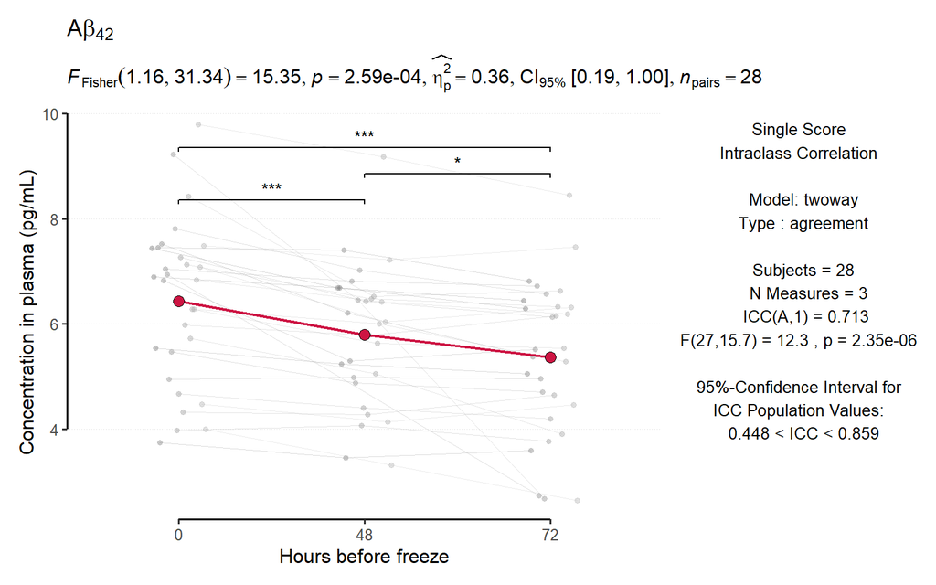

## $\text{Ratio } \frac{A\beta_{42}}{A\beta_{40}}$

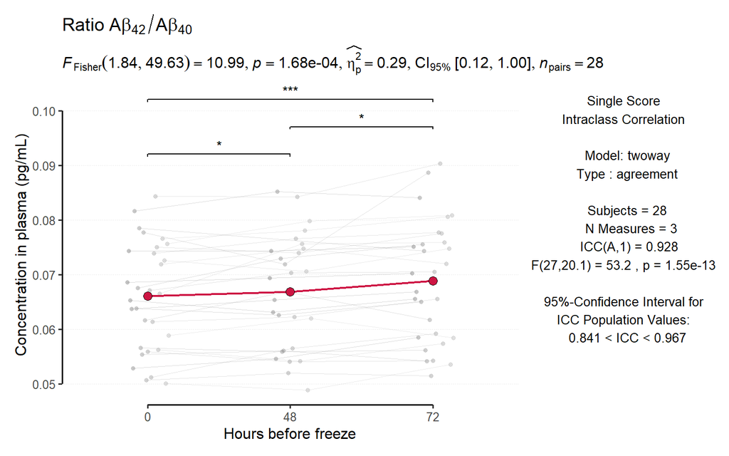

# Acknowledgments

We would like to thank WRAP and WADRC participants and staff for their contributions. Without their efforts, this research would not be possible. Funding for this work was provided by NIH grants R01- AG027161, and P30-AG062715 with further support from CTSA (UL1TR000427) and philanthropy through the UW Initiative to End Alzheimer’s.

$$\\[0.25in]$$